# Wprowadzenie do ggplot2 – funkcja qplot

Materiały zawierają wprowadzenie do pakietu ggplot2, skupiają się na funkcji qplot, która jest podstawową funkcją do tworzenia wizualizacji.

Pakiet **ggplot2** został stworzony przez dr Hadleya Wickhama, który jest również twórcą takich pakietów jak **reshape**, **reshape2**, **plyr**, **dplyr** oraz ułatwiających tworzenie własnych pakietów **devtools** oraz **testthat**.

Dr Hadley Wickham jest również odpowiedzialny za tworzenie **Rstudio** oraz współpracuje przy tworzeniu wielu pakietów (np. **shiny**). Dodatkowo zasiada w *R–foundation* (**R Core Team**) – organizacji, która zajmuje się tworzeniem i usprawnianiem pakietu statystycznego R. Jest uznanym i często zapraszanym na konferencje twórcą i propagatorem pakietu *R*. Swój doktorat napisał np. wizualizacji danych.

## The Grammar of Graphics

Jest stworzonym przez Wilkinsona (2005) językiem opisu wizualizacji danych, który opiera się na szczegółowym opisie poszczególnych elementów przedstawiania danych statystycznych w przystępny sposób. Wickham stworzył implementację tego języka określając ją *layered grammar of graphics*.

Język można scharakteryzować następująco:

- określony jest zbiór danych (data),
- który chcemy przedstawić (zmapować, mapping) z odpowiednimi typami wizualizacji danych (aesthetic),
- za pomocą obiektów geometrycznych (geom), które zawierają m.in. linie, punkty.
- Dodatkowo chcemy przedstawić pewne miary statystyczne (stat), które mają opisywać prezentowany zbiór danych.
- Chcemy również aby każdy wykres miał określoną skalę (scale) oraz układ współrzędnych (coord).
- Interesuje nas również przedstawienie danych, które określają przynależność do poszczególnych grup (facet).

## Opis składni funkcji qplot

Podstawową funkcją funkcją jest qplot, którą można rozwinąć jako *quick plot*. Jest to funkcja, która oferuje najważniejsze argumenty, które służą do tworzenia wykresu.

```r
library(ggplot2)
library(scales)
```

Składnia procedury jest następująca:

```r
  qplot(x, y = NULL, ..., data, facets = NULL,
    margins = FALSE, geom = "auto", stat = list(NULL),
    position = list(NULL), xlim = c(NA, NA),
    ylim = c(NA, NA), log = "", main = NULL,
    xlab = deparse(substitute(x)),
    ylab = deparse(substitute(y)), asp = NA)
```

Poszczególne argumenty odpowiadają za:

- x – oś OX (odciętych)
- y – oś OY (rzędnych)
- data – zbiór danych
- facet – wskazanie zmiennych dla których chcemy stworzyć oddzielne wizualizacje
- margins – wskazuje czy chcemy wyświetlić marginesy na wykresie
- geom – określa geometrię, którą chcemy zastosować
- stat – wskazujemy (o ile chcemy) statystyki do przedstawienia na wykresie
- xlim, ylim – określają zakres osi
- xlab, ylab – określają etykiety osi
- main – określa typ
- asp – określa relację x/y
- log – wskazujemy transformację logarytmiczną osi ('x','y','xy')

Natomiast, jak w dużej części funkcji, pojawia się w funkcji symbol …, który określa możliwość przekazywania arumentów do poszczególnych elementów wykresu (np. size, colour, fill).

Poniżej utworzymy pierwszy, prosty wykres rozrzutu, który przedstawia zależność między dochodem w 2005 a 2013 roku.

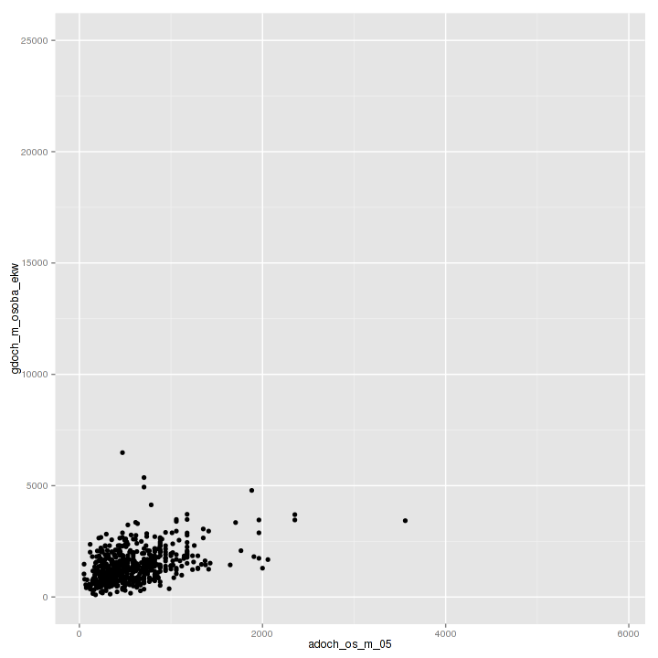

```r
qplot(x=adoch_os_m_05, ### wskazanie osi OX
      y=gdoch_m_osoba_ekw, ### wskazanie osi OY
      data=gosp, ### wskazanie zbioru danych
      geom='point') ### geom = 'point' określa, że korzystamy z geometrii punktowej
```

```r
p<-qplot(x=adoch_os_m_05, ### wskazanie osi OX
      y=gdoch_m_osoba_ekw, ### wskazanie osi OY
      data=gosp[,c('adoch_os_m_05','gdoch_m_osoba_ekw')], ### wskazanie zbioru danych
      geom='point') ### geom = 'point' określa, że korzystamy z geometrii punktowej

### stwórzmy podsumowanie
summary(p)
```

```
data: adoch_os_m_05, gdoch_m_osoba_ekw [23804x2]
mapping:  x = adoch_os_m_05, y = gdoch_m_osoba_ekw
faceting: facet_null()
-----------------------------------
geom_point:
stat_identity:
position_identity: (width = NULL, height = NULL)
```

Powyższy wydruk zawiera informacje, które wskazują poszczególne elementy wykresu:

- data – wskazane są zmienne, które zostały wczytane oraz wymiar zbioru (wiersze x kolumny)
- mapping – określają zmapowane zmienne. W tym przypadku zmapowaliśmy jedynie argumenty x oraz y
- faceting – wskazuje zmienne, które użyliśmy do tworzenia oddzielnych wykresów (w tym przypadku nie mamy żadnych więc pojawia się opcja facet_null())

Poniżej kreski pojawiają się poszczególne informacje określające geometrię (geom*), statystyki (stat*) oraz pozycje (position_).

Chciałbym wskazać jeszcze jeden istotny element. Tworząc wykres warto wziąć pod uwagę ograniczenie zbioru danych do wykorzystywanych zmiennych. Jest to istotne w przypadku gdy korzystamy z dużego zbioru danych, zawierającego bardzo dużo zmiennych. Poniżej porównanie działania dwóch funkcji.

```r
#### wybranie tylko potrzebnych zmiennych
system.time(p<-qplot(x=adoch_os_m_05, ### wskazanie osi OX
      y=gdoch_m_osoba_ekw, ### wskazanie osi OY
      data=gosp[,c('adoch_os_m_05','gdoch_m_osoba_ekw')], ### wskazanie zbioru danych
      geom='point') ### geom = 'point' określa, że korzystamy z geometrii punktowej
)
```

```
   user  system elapsed
  0.004   0.000   0.007
```

```r
#### wybranie wszystkch zmiennych
system.time(p<-qplot(x=adoch_os_m_05, ### wskazanie osi OX
      y=gdoch_m_osoba_ekw, ### wskazanie osi OY
      data=gosp, ### wskazanie zbioru danych
      geom='point') ### geom = 'point' określa, że korzystamy z geometrii punktowej
)
```

```
   user  system elapsed
  1.584   0.000   1.585
```

Wybranie tylko interesujących zmiennych przyśpieszyło działanie funkcji ponad 200 razy.

Mając to na uwadze, stwórzmy rozbudujmy wykres używając dodatkowych opcji:

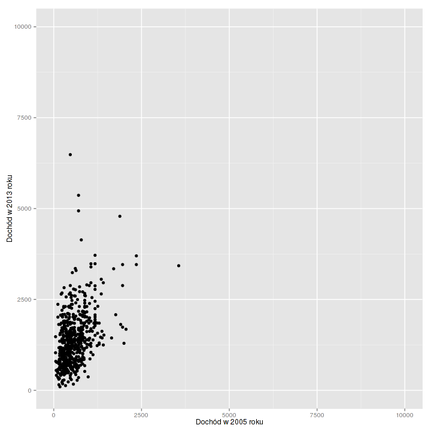

```r
p<-qplot(x=adoch_os_m_05, ### wskazanie osi OX
      y=gdoch_m_osoba_ekw, ### wskazanie osi OY
      data=gosp[,c('adoch_os_m_05','gdoch_m_osoba_ekw')], ### wskazanie zbioru danych
      geom='point',  ### geom = 'point' określa, że korzystamy z geometrii punktowej
      xlab='Dochód w 2005 roku', ### opis osi OX
      ylab='Dochód w 2013 roku', ### opis osi OY
      xlim=c(0,10000),  ### określenie zakresu osi OX
      ylim=c(0,10000)) ### określenie zakresu osi OY
### wywołanie obiektu (możemy również tworzyć wizualizacje bez przypisywania do obiektów)
plot(p)
```

Natomiast jeżeli chcemy wywołać ostatni stworzony wykres, możemy skorzystać z funkcji *last_plot()*.

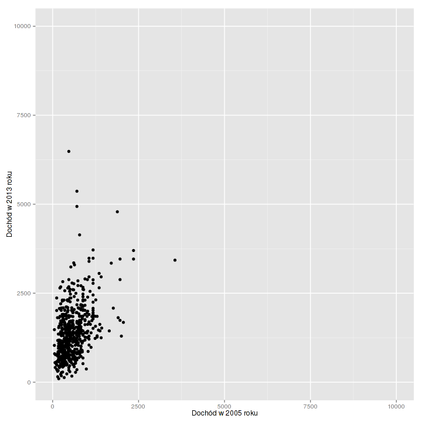

```r
last_plot()
```

Możemy dodać do wykresu linię regresji, która wskaże nam kierunek zależności między tymi zmiennymi. Kolejne elementy określamy w argumencie *geom* podając wektor tekstowy. Dostępne geometrie, które są dostępne w ggplot są następujące:

- geom_abline – Line specified by slope and intercept.
- geom_area – Area plot.
- geom_bar – Bars, rectangles with bases on x-axis
- geom_bin2d – Add heatmap of 2d bin counts.
- geom_blank – Blank, draws nothing.
- geom_boxplot – Box and whiskers plot.
- geom_contour – Display contours of a 3d surface in 2d.
- geom_crossbar – Hollow bar with middle indicated by horizontal line.
- geom_density – Display a smooth density estimate.
- geom_density2d – Contours from a 2d density estimate.
- geom_dotplot – Dot plot
- geom_errorbar – Error bars.
- geom_errorbarh – Horizontal error bars
- geom_freqpoly – Frequency polygon.
- geom_hex – Hexagon bining.
- geom_histogram – Histogram
- geom_hline – Horizontal line.
- geom_jitter – Points, jittered to reduce overplotting.
- geom_line – Connect observations, ordered by x value.
- geom_linerange – An interval represented by a vertical line.
- geom_map – Polygons from a reference map.
- geom_path – Connect observations in original order
- geom_point – Points, as for a scatterplot
- geom_pointrange – An interval represented by a vertical line, with a point in the middle.
- geom_polygon – Polygon, a filled path.
- geom_quantile – Add quantile lines from a quantile regression.
- geom_raster – High-performance rectangular tiling.
- geom_rect – 2d rectangles.
- geom_ribbon – Ribbons, y range with continuous x values.
- geom_rug – Marginal rug plots.
- geom_segment – Single line segments.
- geom_smooth – Add a smoothed conditional mean.
- geom_step – Connect observations by stairs.
- geom_text – Textual annotations.
- geom_tile – Tile plane with rectangles.
- geom_violin – Violin plot.
- geom_vline – Line, vertical.

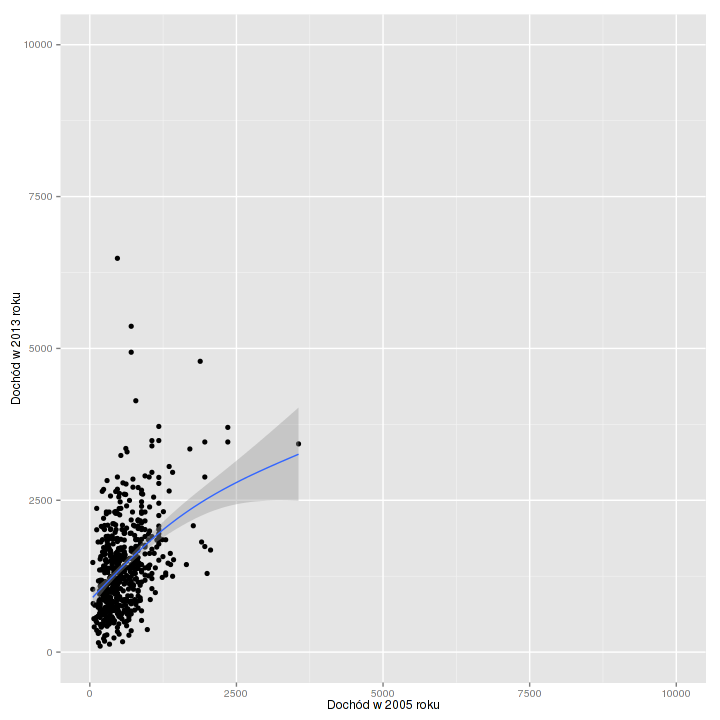

```r
p<-qplot(x=adoch_os_m_05, ### wskazanie osi OX
      y=gdoch_m_osoba_ekw, ### wskazanie osi OY
      data=gosp[,c('adoch_os_m_05','gdoch_m_osoba_ekw')], ### wskazanie zbioru danych
      geom=c('point','smooth'),  ### geom = 'point' określa, że korzystamy z geometrii punktowej
      xlab='Dochód w 2005 roku', ### opis osi OX
      ylab='Dochód w 2013 roku', ### opis osi OY
      xlim=c(0,10000),  ### określenie zakresu osi OX
      ylim=c(0,10000)) ### określenie zakresu osi OY
### wywołanie obiektu (możemy również tworzyć wizualizacje bez przypisywania do obiektów)
plot(p)
```

**ggplot2** umożliwia tworzenie wykresów, które pozwalają na porównanie poszczególnych grup. Możemy wykorzystać do tego kilka opcji. Skorzystamy z najprostrzej tj. każdy punkt będzie miał odpowiedni kolor uzależniony od przynależności do klasy miejscowości. Chcemy sprawdzić czy występują różnice w zmianie dochodów w badanych gospodarstwach domowych.

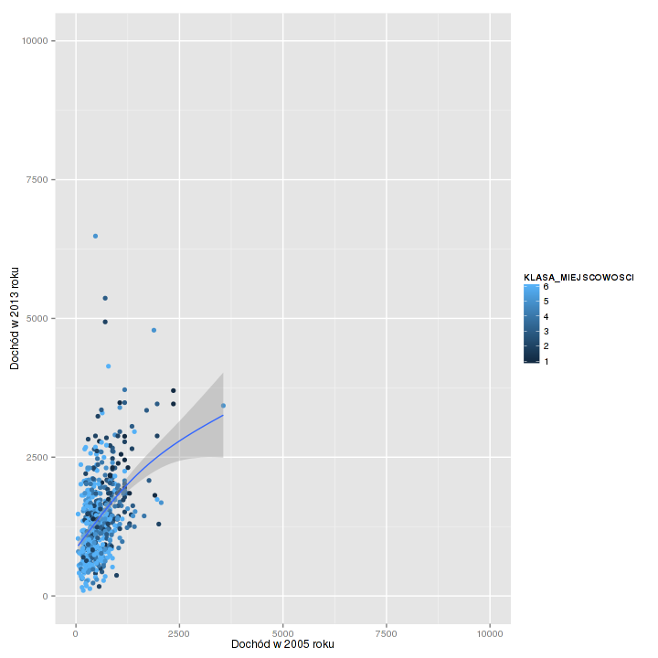

```r
p<-qplot(x=adoch_os_m_05, ### wskazanie osi OX
      y=gdoch_m_osoba_ekw, ### wskazanie osi OY
      data=gosp[,c('adoch_os_m_05','gdoch_m_osoba_ekw','KLASA_MIEJSCOWOSCI')], ### wskazanie zbioru danych
      geom=c('point','smooth'),  ### geom = 'point' określa, że korzystamy z geometrii punktowej
      colour=KLASA_MIEJSCOWOSCI,
      xlab='Dochód w 2005 roku', ### opis osi OX
      ylab='Dochód w 2013 roku', ### opis osi OY
      xlim=c(0,10000),  ### określenie zakresu osi OX
      ylim=c(0,10000)) ### określenie zakresu osi OY

### wywołanie obiektu (możemy również tworzyć wizualizacje bez przypisywania do obiektów)
plot(p)
```

Nie do końca otrzymaliśmy to co chceliśmy. Domyślnie zmienna określająca klasę miejscowości została potraktowana jako zmienna ciągła. Aby kolor dotyczył poszczególnych grup należy najpierw zmienić (bądź w ciele funkcji wpisać) typ zmiennej na factor.

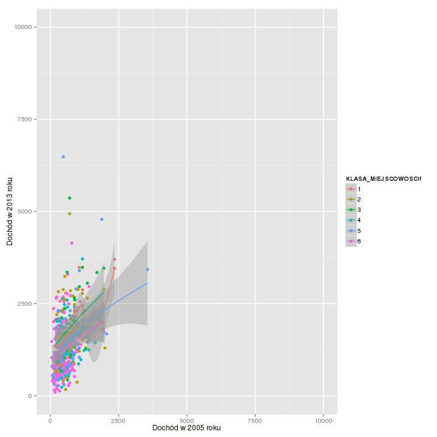

```r
gosp$KLASA_MIEJSCOWOSCIf<-as.factor(gosp$KLASA_MIEJSCOWOSCI)
### lub równoważnie w ciele funkcji qplot (colour=as.factor(KLASA_MIEJSCOWOSCI))

p<-qplot(x=adoch_os_m_05, ### wskazanie osi OX
      y=gdoch_m_osoba_ekw, ### wskazanie osi OY
      data=gosp[,c('adoch_os_m_05','gdoch_m_osoba_ekw','KLASA_MIEJSCOWOSCIf')], ### wskazanie zbioru danych
      geom=c('point','smooth'),  ### geom = 'point' określa, że korzystamy z geometrii punktowej
      colour=KLASA_MIEJSCOWOSCIf,
      xlab='Dochód w 2005 roku', ### opis osi OX
      ylab='Dochód w 2013 roku', ### opis osi OY
      xlim=c(0,10000),  ### określenie zakresu osi OX
      ylim=c(0,10000)) ### określenie zakresu osi OY
plot(p)
```

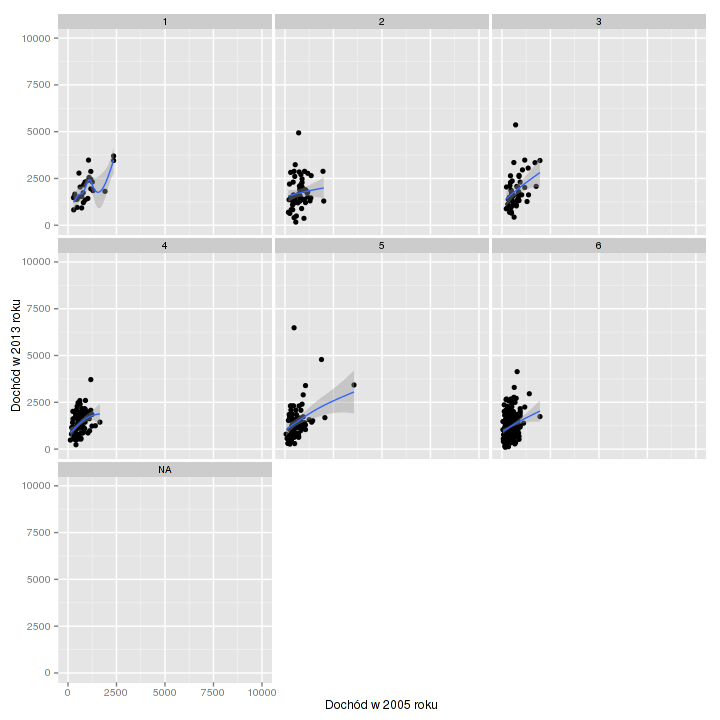

```r
p<-qplot(x=adoch_os_m_05, ### wskazanie osi OX
      y=gdoch_m_osoba_ekw, ### wskazanie osi OY
      data=gosp[,c('adoch_os_m_05','gdoch_m_osoba_ekw','KLASA_MIEJSCOWOSCIf')], ### wskazanie zbioru danych
      geom=c('point','smooth'),  ### geom = 'point' określa, że korzystamy z geometrii punktowej
      facets=~KLASA_MIEJSCOWOSCIf, ### określenie zmiennej określającej wykresy
      xlab='Dochód w 2005 roku', ### opis osi OX
      ylab='Dochód w 2013 roku', ### opis osi OY
      xlim=c(0,10000),  ### określenie zakresu osi OX
      ylim=c(0,10000)) ### określenie zakresu osi OY
plot(p)
```

Opcja ta ma specyficzną składnię:

- .~ zmienna – oznacza stworzenie zmiennej grupującej tworzacej panele kolumnowe
- zmienna~. – oznacza stworzenie zmiennej grupującej tworzacej panele wierszowe
- ~zmienna – oznacza stworzenie zmiennej grupującej tworzacej panele bez rozróżnienia na wierszcze czy kolumny.

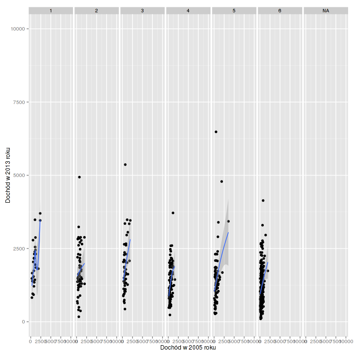

```r
### .~ zmienna
p<-qplot(x=adoch_os_m_05, ### wskazanie osi OX
      y=gdoch_m_osoba_ekw, ### wskazanie osi OY
      data=gosp[,c('adoch_os_m_05','gdoch_m_osoba_ekw','KLASA_MIEJSCOWOSCIf')], ### wskazanie zbioru danych
      geom=c('point','smooth'),  ### geom = 'point' określa, że korzystamy z geometrii punktowej
      facets=.~KLASA_MIEJSCOWOSCIf, ### określenie zmiennej określającej wykresy
      xlab='Dochód w 2005 roku', ### opis osi OX
      ylab='Dochód w 2013 roku', ### opis osi OY
      xlim=c(0,10000),  ### określenie zakresu osi OX
      ylim=c(0,10000)) ### określenie zakresu osi OY
plot(p)
```

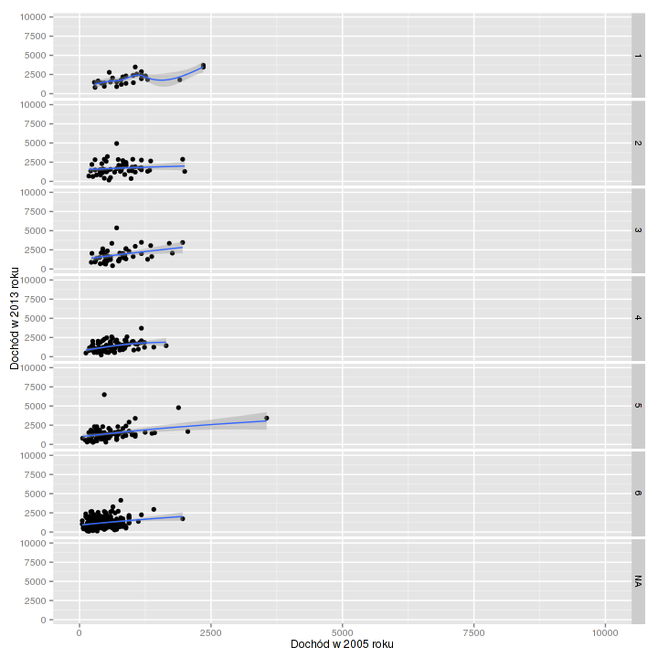

```r
### zmienna~.
p<-qplot(x=adoch_os_m_05, ### wskazanie osi OX
      y=gdoch_m_osoba_ekw, ### wskazanie osi OY
      data=gosp[,c('adoch_os_m_05','gdoch_m_osoba_ekw','KLASA_MIEJSCOWOSCIf')], ### wskazanie zbioru danych
      geom=c('point','smooth'),  ### geom = 'point' określa, że korzystamy z geometrii punktowej
      facets=KLASA_MIEJSCOWOSCIf~., ### określenie zmiennej określającej wykresy
      xlab='Dochód w 2005 roku', ### opis osi OX
      ylab='Dochód w 2013 roku', ### opis osi OY
      xlim=c(0,10000),  ### określenie zakresu osi OX
      ylim=c(0,10000)) ### określenie zakresu osi OY
plot(p)
```

## Operator specjalny %+% oraz %+replace%

Przypisywanie wykresów do obiektów ma bardzo dużą zaletę. Załóżmy, że stworzyliśmy wykres i chcemy go wykorzystać do tworzenia kolejnych w pętli. Możliwe jest wykonanie tego dzięki operatorim %+% oraz %+repace%.

**Operator %+% odpowiedzialny jest za zmianę zbioru danych**, i dodatkowo:

- uneval: replace current aesthetics
- layer: add new layer
- theme: update plot theme
- scale: replace current scale
- coord: override current coordinate system
- facet: override current coordinate faceting

**Operator %+replace% za zmianę poszczególnych elementów wykresu (wyglądu tematu, theme)**.

Załóżmy, że chcielibyśmy wykonać ten sam wykres, który znajduje się powyżej (z facets = ~KLASA_MIEJSCOWOSCI), jednak nie chcemy tworzyć lub przeklejać całego wykresu tylko zmienić jego element. W pierwszej kolejności musimy zmienić zbiór danych na których pracujemy na taki, który zawiera zmienną WOJEWÓDZTWO wg której będziemy go tworzyć.

```r
p<-qplot(x=adoch_os_m_05, ### wskazanie osi OX
      y=gdoch_m_osoba_ekw, ### wskazanie osi OY
      data=gosp[,c('adoch_os_m_05','gdoch_m_osoba_ekw','KLASA_MIEJSCOWOSCIf')], ### wskazanie zbioru danych
      geom=c('point','smooth'),  ### geom = 'point' określa, że korzystamy z geometrii punktowej
      facets=~KLASA_MIEJSCOWOSCIf, ### określenie zmiennej określającej wykresy
      xlab='Dochód w 2005 roku', ### opis osi OX
      ylab='Dochód w 2013 roku', ### opis osi OY
      xlim=c(0,10000),  ### określenie zakresu osi OX
      ylim=c(0,10000)) ### określenie zakresu osi OY

summary(p)
```

```
data: adoch_os_m_05, gdoch_m_osoba_ekw, KLASA_MIEJSCOWOSCIf [23804x3]
mapping:  x = adoch_os_m_05, y = gdoch_m_osoba_ekw
scales:   x, xmin, xmax, xend, xintercept, y, ymin, ymax, yend, yintercept, ymin_final, ymax_final
faceting: facet_wrap(KLASA_MIEJSCOWOSCIf)
-----------------------------------
geom_point:
stat_identity:
position_identity: (width = NULL, height = NULL)

geom_smooth:
stat_smooth:
position_identity: (width = NULL, height = NULL)
```

```r
### dokonaliśmy teraz zmiany zbioru danych
p<-p %+% gosp[,c('adoch_os_m_05','gdoch_m_osoba_ekw','KLASA_MIEJSCOWOSCIf','WOJEWODZTWO')]

summary(p)
```

```
data: adoch_os_m_05, gdoch_m_osoba_ekw, KLASA_MIEJSCOWOSCIf, WOJEWODZTWO [23804x4]
mapping:  x = adoch_os_m_05, y = gdoch_m_osoba_ekw
scales:   x, xmin, xmax, xend, xintercept, y, ymin, ymax, yend, yintercept, ymin_final, ymax_final
faceting: facet_wrap(KLASA_MIEJSCOWOSCIf)
-----------------------------------
geom_point:
stat_identity:
position_identity: (width = NULL, height = NULL)

geom_smooth:
stat_smooth:
position_identity: (width = NULL, height = NULL)
```

Teraz możemy spróbować zamienić facets na zmienną określającą województwo. Musimy tego dokonać funkcją facet_wrap (na której będziemy się później skupiać).

```r
p<-p %+% facet_wrap(~WOJEWODZTWO)
summary(p)
```

```
data: adoch_os_m_05, gdoch_m_osoba_ekw, KLASA_MIEJSCOWOSCIf, WOJEWODZTWO [23804x4]
mapping:  x = adoch_os_m_05, y = gdoch_m_osoba_ekw
scales:   x, xmin, xmax, xend, xintercept, y, ymin, ymax, yend, yintercept, ymin_final, ymax_final
faceting: facet_wrap(WOJEWODZTWO)
-----------------------------------
geom_point:
stat_identity:
position_identity: (width = NULL, height = NULL)

geom_smooth:
stat_smooth:
position_identity: (width = NULL, height = NULL)
```

Jak widać pakiet ggplot2 jest potężnym narzędziem, które zdecydowanie ułatwia pracę przy tworzeniu szeregu wykresów.

## Inne typy wykresów

Póki co zajęliśmy się jednym typem (geometrią) wizualizacji. Teraz czas na kolejne, które możemy przedstawić za pomocą funkcji qplot. Jako pierwszą zajmiemy się wiuzualizacją rozkładu zmiennej z wykorzystaniem histogramu. Będziemy chcieli sprawdzić jak prezentuje się rozkład dochodów ekwiwalentnych na osobę w 2013 roku.

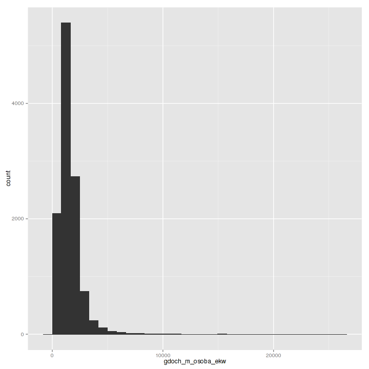

```r
### rozkład dochodów
p<-qplot(x=gdoch_m_osoba_ekw,
         data=gosp[,c('adoch_os_m_05','gdoch_m_osoba_ekw','KLASA_MIEJSCOWOSCIf','WOJEWODZTWO')],
         geom='histogram')
plot(p)
```

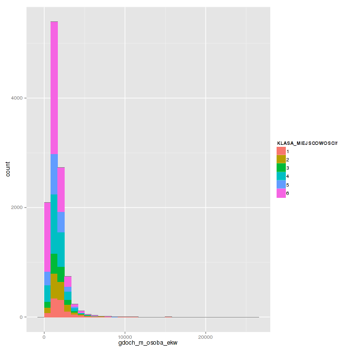

```r
### dodamy teraz kolor wg klasy miejscowosci
p %+% aes(fill=KLASA_MIEJSCOWOSCIf)
```

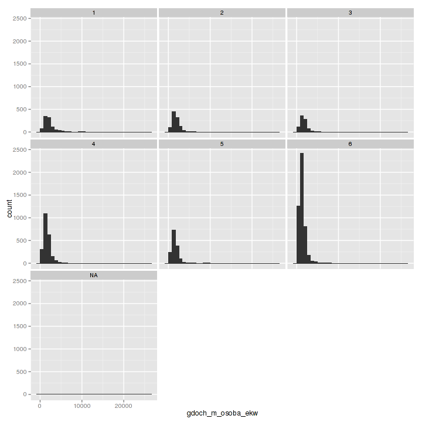

```r
### niestety wykres nie jest czytelny, należy zmienić  wypełnienie na oddzielne wykresy

p %+% facet_wrap(~KLASA_MIEJSCOWOSCIf)
```

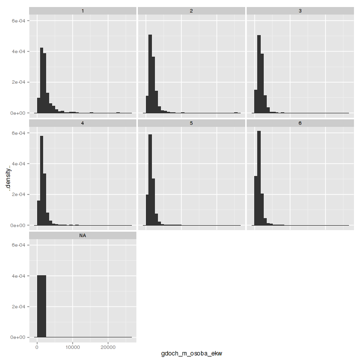

```r
## a także prezentację w postaci gęstości prawdopodobieństwa, a nie częstości

p %+% facet_wrap(~KLASA_MIEJSCOWOSCIf) %+% aes(y=..density..)
```

W ten sposób możemy przejść do zmiany typu wykresu z histogramu na rozkład gęstości zmiennej (aby być precyzyjnym graficznego przedstawienia estymacji parametrów rozkładu metodą jądrową). Niestety operator %+% i musimy wprowadzić zmiany w obiekcie p na nowo go tworząc.

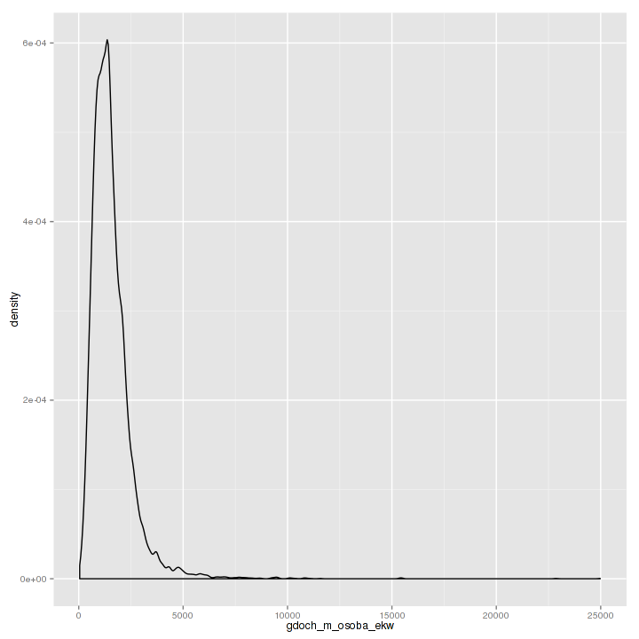

```r
p<-qplot(x=gdoch_m_osoba_ekw,
         data=gosp[,c('adoch_os_m_05','gdoch_m_osoba_ekw','KLASA_MIEJSCOWOSCIf','WOJEWODZTWO')],
         geom='density')
plot(p)
```

Natomiast kolejne zmiany możemy wykonywać podobnie jak w przypadku poprzednich wykresów możemy zmieniać elementy wykresu operatorem %+%.

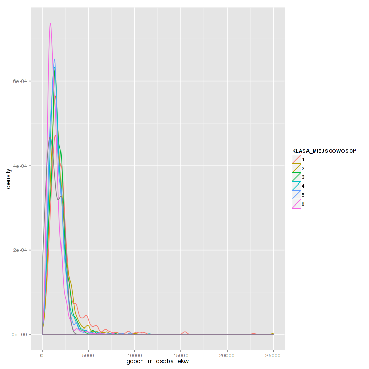

```r
p %+% aes(colour=KLASA_MIEJSCOWOSCIf)
```

Możemy również zmienić z koloru obramowania na wypełnienie oraz skalę logarytmiczną

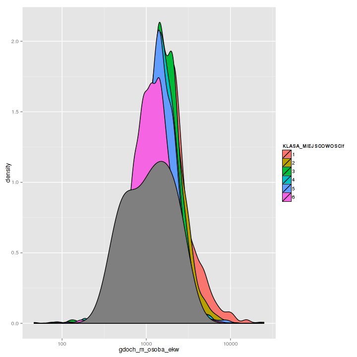

```r
p %+% aes(fill=KLASA_MIEJSCOWOSCIf) %+% scale_x_log10()
```

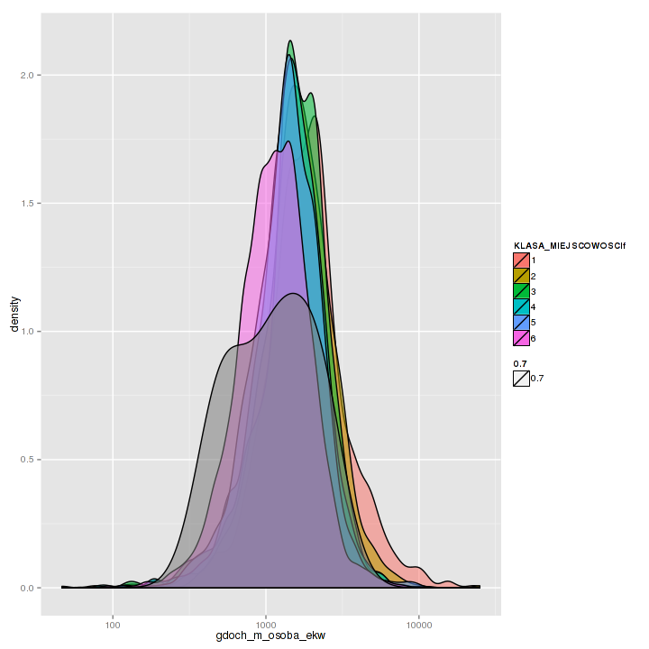

```r
### przypisanie do obiektu
p<-p %+% aes(fill=KLASA_MIEJSCOWOSCIf) %+% scale_x_log10()

### ustalenie przezroczystności (działa gdy zainstalowany jest pakiet scales)
p %+% aes(alpha=0.7)
```